# MScA, Linear and Nonlinear Models (31010) Week 3, Workshop 2: Using copulas for climate anomalies detection

Yuri Balasanov, © iLykei 2016

# 1 Introduction

This project is based with some significant changes on the study published in: [Motivating Complex Dependence Structures in Data Mining: A Case Study with Anomaly Detection in Climate, Shih-Chieh Kao, Auroop R. Ganguly, and Karsten Steinhaeuser, 2009 IEEE International Conference on Data Mining Workshops](https://pdfs.semanticscholar.org/13a9/c98368018401a39c17a6232a475f5ead95f5.pdf)

Data set for this project is part of NCEP_Reanalysis 2 data provided by the NOAA/OAR/ESRL PSD, Boulder, Colorado, USA, from their [web site](http://www.esrl.noaa.gov/psd/).  
NCEP2 data are collected from a world-wide grid of sensors providing 2.5°$\times$ 2.5° spatial resolution, i.e. sesors make a grid with 2.5° steps both in longitude and latitude directions.  
The data variables for this project are monthly averages of surface air temperature and precipitable water at the location of the sensor beginning from January 1-st 1979 until end of June, 2016.  
Files can be downloaded from [here](https://www.esrl.noaa.gov/psd/data/gridded/reanalysis/). We select one location from the grid representing Miami, FL area (80.1918° W, 25.7617° N).

**Precipitable water** is the depth of water in a column of the atmosphere, if all the water in that column were precipitated as rain. As a depth, the precipitable water is measured in millimeters or inches.

Surface air temperature and precipitable water are related. In general, higher air temperature means that water evaporation is more intensive, as a result amount of precipitable water increases.  
Of course, this effect may be different in different locations.  
But as we will see below it is clearly observed in Miami region.

Climate anomaly that is analyzed in this project is an abnormal combination of high air temperature and low precipitable water index in any given month.

# 2 Anomaly detection techniques

Anomaly or rare events detection is an important problem for many applications besides analysis of weather anomalies, for example, financial portfolio management, fraud detection, cyber security, etc.  
There are many efficient methods for anomaly detection with the basic idea of all of them: define a boundary separating “normal” events or observations and anomalies; then check if new observation can be categorized as normal or not.  
The key challenge of each method is to find a quantile corresponding to deep tail of the distribution of variable of interest.  
In case when variable of interest is univariate a commonly used method, for example, is [extreme value theory](http://ilykei.com/api/fileProxy/documents%2FMScA%20Real%20Time%20Analysis%2032005%2FMScA%20Real%20Time%20Analysis%2032005%20Lecture%206%2FMScA_RealTimeAnalysis32005_Week6_Workshop.html).

However, if the variable is multivariate and an anomali can be described as a combination of levels of its components, the universe of available methods becomes quite small.  
If components of the multivariate variable are independent then the problem is reduced to finding quantiles of one-dimensional marginal ditributions.  
In the case when the variable has multivariate normal distribution, one-dimensional quantile is replaced with an concentration ellipsoid of multivariate normal distribution which gives a simple analytical solution to the problem.  
But if marginal distributions are not normal and variables are not independent the problem becomes quite challenging.

In the following sections anomaly detection problem is solved for a byvariate anomalies when the underlying variables are not Gaussian and may have nonlinear relationship.

The method is based on copulas and quantile regression.

# 3 Data preparation

```r
suppressWarnings(library(RNetCDF))
suppressWarnings(library(copula))
suppressWarnings(library(MASS))
```

Import data with montly air temperature `air.mon.mean.nc` and monthly precipitable water `pr_wtr.eatm.mon.mean.nc`.  
The format of the files is NetCDF. In order to import these data use library `RNetCDF`

Importing data requires 2 functions: `open.nc()` creates a pointer to the file with the data; `read.nc()` reads the data.

## 3.1 Air temperature

```r
# Temperature
pointTemper<-open.nc(con=paste(dataPath,"air.mon.mean.nc",sep="/"), write=FALSE, share=FALSE, prefill=TRUE)
temperMon<-read.nc(pointTemper,unpack=T)
names(temperMon)
```

```
## [1] "level"     "lat"       "lon"       "time"      "time_bnds" "air"
```

The temperature file shows 17 levels of atmospheric pressure at which the data are collected (millibars).  
Only the first level, corresponding to surface is used.

```r
temperMon$level
```

```
##  [1] 1000  925  850  700  600  500  400  300  250  200  150  100   70   50
## [15]   30   20   10
```

The location latitude coordinates are shown at 73 levels ranging from 90° (N) to -90° (S).

```r
temperMon$lat
```

```
##  [1]  90.0  87.5  85.0  82.5  80.0  77.5  75.0  72.5  70.0  67.5  65.0
## [12]  62.5  60.0  57.5  55.0  52.5  50.0  47.5  45.0  42.5  40.0  37.5
## [23]  35.0  32.5  30.0  27.5  25.0  22.5  20.0  17.5  15.0  12.5  10.0
## [34]   7.5   5.0   2.5   0.0  -2.5  -5.0  -7.5 -10.0 -12.5 -15.0 -17.5
## [45] -20.0 -22.5 -25.0 -27.5 -30.0 -32.5 -35.0 -37.5 -40.0 -42.5 -45.0
## [56] -47.5 -50.0 -52.5 -55.0 -57.5 -60.0 -62.5 -65.0 -67.5 -70.0 -72.5
## [67] -75.0 -77.5 -80.0 -82.5 -85.0 -87.5 -90.0
```

The location longitude coordinates are shown at 144 levels ranging from 0° (prime meridian, based at the Royal Observatory, Greenwich, in London) going around the world in Eastern direction to 357.5°.

```r
temperMon$lon
```

```
##   [1]   0.0   2.5   5.0   7.5  10.0  12.5  15.0  17.5  20.0  22.5  25.0
##  [12]  27.5  30.0  32.5  35.0  37.5  40.0  42.5  45.0  47.5  50.0  52.5
##  [23]  55.0  57.5  60.0  62.5  65.0  67.5  70.0  72.5  75.0  77.5  80.0
##  [34]  82.5  85.0  87.5  90.0  92.5  95.0  97.5 100.0 102.5 105.0 107.5
##  [45] 110.0 112.5 115.0 117.5 120.0 122.5 125.0 127.5 130.0 132.5 135.0
##  [56] 137.5 140.0 142.5 145.0 147.5 150.0 152.5 155.0 157.5 160.0 162.5
##  [67] 165.0 167.5 170.0 172.5 175.0 177.5 180.0 182.5 185.0 187.5 190.0
##  [78] 192.5 195.0 197.5 200.0 202.5 205.0 207.5 210.0 212.5 215.0 217.5
##  [89] 220.0 222.5 225.0 227.5 230.0 232.5 235.0 237.5 240.0 242.5 245.0
## [100] 247.5 250.0 252.5 255.0 257.5 260.0 262.5 265.0 267.5 270.0 272.5
## [111] 275.0 277.5 280.0 282.5 285.0 287.5 290.0 292.5 295.0 297.5 300.0
## [122] 302.5 305.0 307.5 310.0 312.5 315.0 317.5 320.0 322.5 325.0 327.5
## [133] 330.0 332.5 335.0 337.5 340.0 342.5 345.0 347.5 350.0 352.5 355.0
## [144] 357.5
```

Finally, the grid of air temperatures is a 4-dimensional array: longitude, latitude, level and the temperature.  
The length of the air temperature sample is 37 years $\times$ 12 + 6 months = 450.

```r
dim(temperMon$air)
```

```
## [1] 144  73  17 450
```

## 3.2 Precipitable water

```r
# Precipitable water
pointWater<-open.nc(con=paste(dataPath,"pr_wtr.eatm.mon.mean.nc",sep="/"), write=FALSE, share=FALSE, prefill=TRUE)
waterMon<-read.nc(pointWater,unpack=T)
names(waterMon)
```

```
## [1] "lat"       "lon"       "time"      "time_bnds" "pr_wtr"
```

```r
waterMon$lat
```

```
##  [1]  90.0  87.5  85.0  82.5  80.0  77.5  75.0  72.5  70.0  67.5  65.0
## [12]  62.5  60.0  57.5  55.0  52.5  50.0  47.5  45.0  42.5  40.0  37.5
## [23]  35.0  32.5  30.0  27.5  25.0  22.5  20.0  17.5  15.0  12.5  10.0
## [34]   7.5   5.0   2.5   0.0  -2.5  -5.0  -7.5 -10.0 -12.5 -15.0 -17.5
## [45] -20.0 -22.5 -25.0 -27.5 -30.0 -32.5 -35.0 -37.5 -40.0 -42.5 -45.0
## [56] -47.5 -50.0 -52.5 -55.0 -57.5 -60.0 -62.5 -65.0 -67.5 -70.0 -72.5
## [67] -75.0 -77.5 -80.0 -82.5 -85.0 -87.5 -90.0
```

```r
waterMon$lon
```

```
##   [1]   0.0   2.5   5.0   7.5  10.0  12.5  15.0  17.5  20.0  22.5  25.0
##  [12]  27.5  30.0  32.5  35.0  37.5  40.0  42.5  45.0  47.5  50.0  52.5
##  [23]  55.0  57.5  60.0  62.5  65.0  67.5  70.0  72.5  75.0  77.5  80.0
##  [34]  82.5  85.0  87.5  90.0  92.5  95.0  97.5 100.0 102.5 105.0 107.5
##  [45] 110.0 112.5 115.0 117.5 120.0 122.5 125.0 127.5 130.0 132.5 135.0
##  [56] 137.5 140.0 142.5 145.0 147.5 150.0 152.5 155.0 157.5 160.0 162.5
##  [67] 165.0 167.5 170.0 172.5 175.0 177.5 180.0 182.5 185.0 187.5 190.0
##  [78] 192.5 195.0 197.5 200.0 202.5 205.0 207.5 210.0 212.5 215.0 217.5
##  [89] 220.0 222.5 225.0 227.5 230.0 232.5 235.0 237.5 240.0 242.5 245.0
## [100] 247.5 250.0 252.5 255.0 257.5 260.0 262.5 265.0 267.5 270.0 272.5
## [111] 275.0 277.5 280.0 282.5 285.0 287.5 290.0 292.5 295.0 297.5 300.0
## [122] 302.5 305.0 307.5 310.0 312.5 315.0 317.5 320.0 322.5 325.0 327.5
## [133] 330.0 332.5 335.0 337.5 340.0 342.5 345.0 347.5 350.0 352.5 355.0
## [144] 357.5
```

```r
dim(waterMon$pr_wtr)
```

```
## [1] 144  73 450
```

Precipitable water variable contains only latitude, longitude and the grid of water observations for 450 months.

## 3.3 Selecting location

Set location to Maiami area (80.1918° W, 25.7617° N).  
Recalculate location longitude from the common format 80.1918° W into 0°-360° range: the format of coordinates used in NCEP 2 files.  
Do it by adding 360°: $-80.1918+360=279.8082$.

```r
#Longitude
# Maiami, FL 80.1918W -> -80.1918+360=279.8082
 lon<-279.8082
#Latitude
# Maiami, FL 25.7617N
 lat<-25.7617
```

Select grid node closiest to Miami.

```r
(idxLon<-temperMon$lon[which.min(abs(temperMon$lon-lon))])
```

```
## [1] 280
```

```r
allLat<-if (lat>=0) {
          temperMon$lat[temperMon$lat>=0]
}   else {
          temperMon$lat[temperMon$lat<0]
}
(idxLat<-temperMon$lat[which.min(abs(temperMon$lat-lat))])
```

```
## [1] 25
```

```r
temperDates<-c(rep(1:12,37),1:6) #months
nTime<-length(temperDates)
```

## 3.4 Normalized temperatures

Create time series of temperature.  
Normalize it.

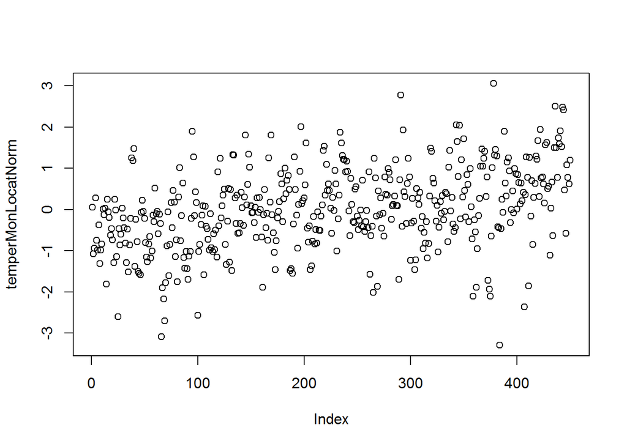

```r
temperMonLocat<-temperMon$air[temperMon$lon==idxLon,temperMon$lat==idxLat,1,]

monMeans<-aggregate(temperMonLocat,by=list(temperDates),mean) #Monthly means
monSd<-aggregate(temperMonLocat,by=list(temperDates),sd) # Monthly standard deviations
mu<-monMeans[temperDates,]$x
sd<-monSd[temperDates,]$x
temperMonLocatNorm<-(temperMonLocat-mu)/sd
plot(temperMonLocatNorm)
```

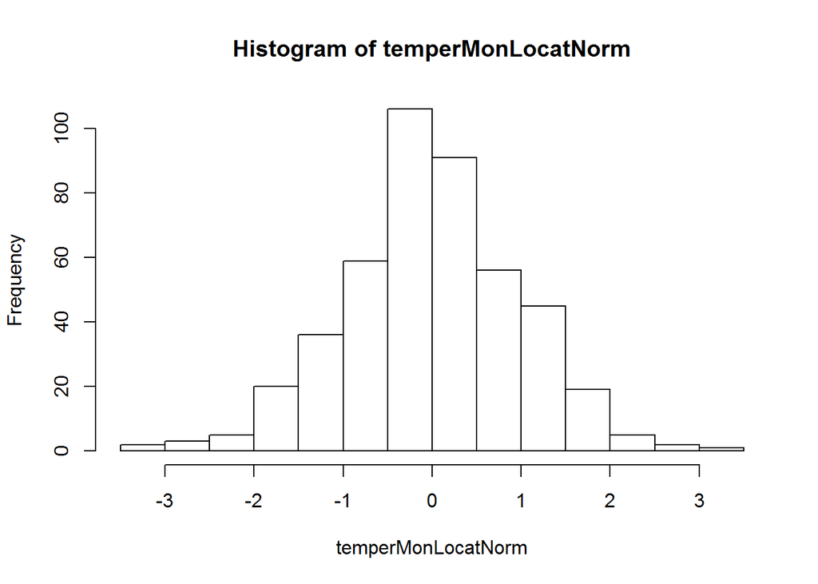

```r
hist(temperMonLocatNorm)
```

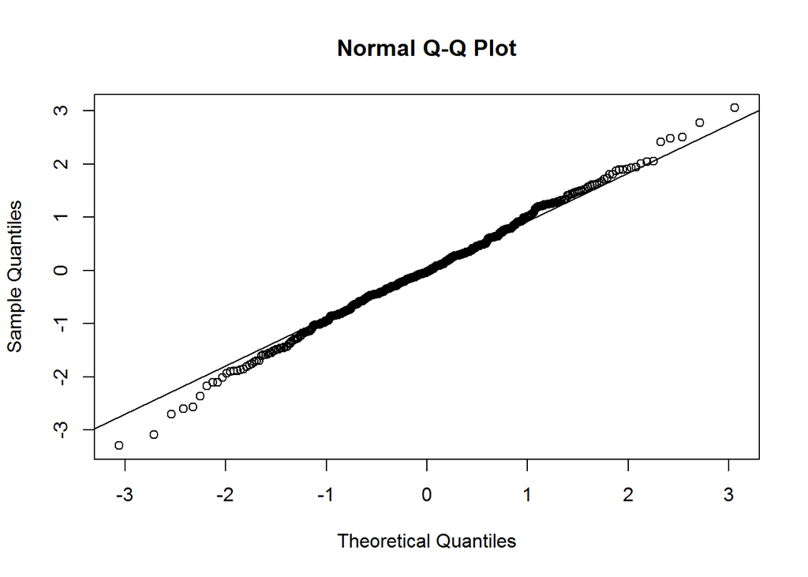

```r
qqnorm(temperMonLocatNorm)
qqline(temperMonLocatNorm)
```

Plotting normalized temperatures clearly shows positive trend combined with downside long tail of the distribution: sign of stable warming with instability of low outliers.

## 3.5 Normalized precipitable water

Create time series of precipitable water.  
Normalize it.

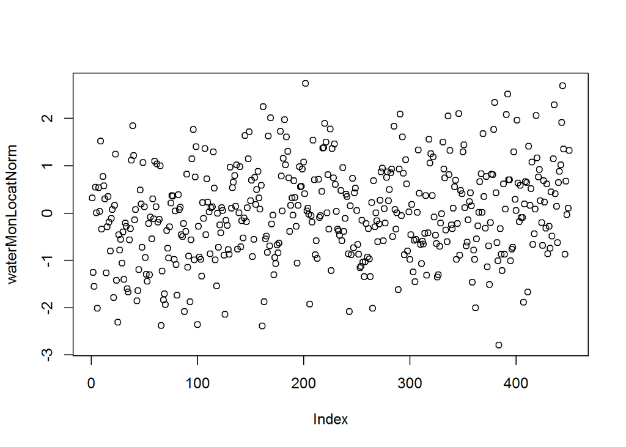

```r
waterMonLocat<-waterMon$pr_wtr[waterMon$lon==idxLon,waterMon$lat==idxLat,]
monMeansW<-aggregate(waterMonLocat,by=list(temperDates),mean)
monSdW<-aggregate(waterMonLocat,by=list(temperDates),sd)
muW<-monMeansW[temperDates,]$x
sdW<-monSdW[temperDates,]$x
waterMonLocatNorm<-(waterMonLocat-muW)/sdW
plot(waterMonLocatNorm)
```

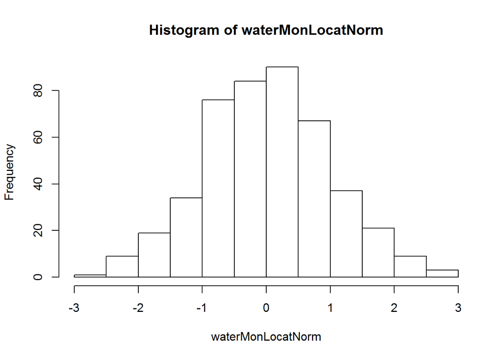

```r
hist(waterMonLocatNorm)
```

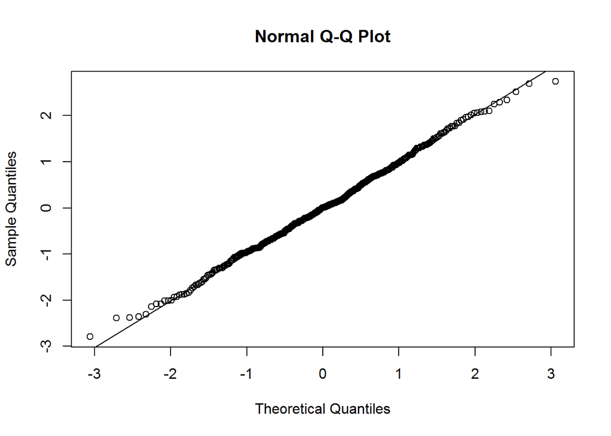

```r
qqnorm(waterMonLocatNorm)
qqline(waterMonLocatNorm)
```

Precipitable water shows short tails which may be consistent with a limitation of the amount of water that can evaporate.  
## Relationship between air temperature and precipitable water

Plot the variables.

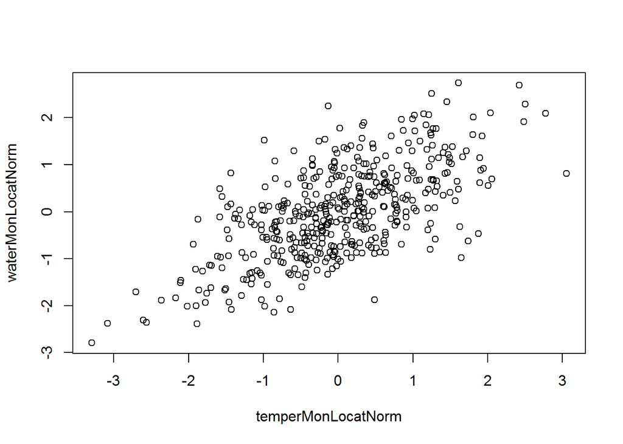

```r
plot(temperMonLocatNorm,waterMonLocatNorm)
```

We observe the expected comonotonic relationship: high temperature - increase in precipitable water due to evaporation.  
The shape of the cloud suggests that there may be a non-Gaussian relationship that cannot be captured by correlation and linear regression.  
**Why?**

Plot empirical copula.

(Skipped Code)

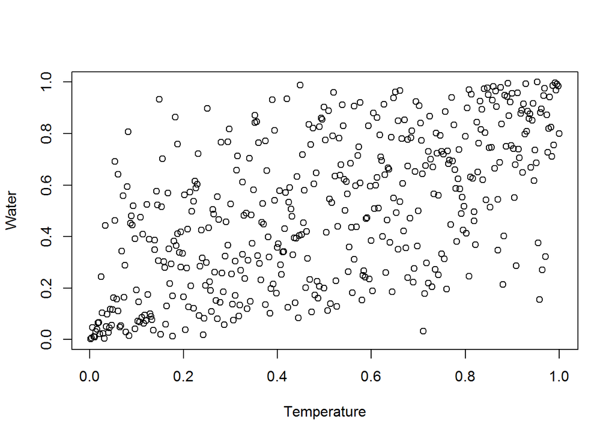

**What are your suggestion for type of copula observed?**

Calculate Pearson, Spearman and Kendall correlation coefficients.

(Skipped Code)

```r
c(Pearson=pearsonCor,Spearman=spearmanCor,Kendall=kendallCor)
```

```
##   Pearson  Spearman   Kendall
## 0.6460037 0.6024381 0.4313110
```

Common Pearson correlation detects more correlation than nonlinear correlation coefficients reacting to non-Gaussian comonotonic tails.

# 4 Fitting Frank copula

Fit Frank copula.

```r
copulaFitData<-cbind(temperMonLocatNorm,waterMonLocatNorm)
Frank.Copula.Fit.Object<-frankCopula(param=5,dim=2)
Frank.Copula.fit<-fitCopula(Frank.Copula.Fit.Object,
          pobs(copulaFitData,ties.method = "average"),
          method = "ml",
          optim.method = "BFGS",
          optim.control = list(maxit=1000))
Frank.Copula.fit
```

```
## fitCopula() estimation based on 'maximum likelihood'
## and a sample of size 450.
##       Estimate Std. Error z value Pr(>|z|)
## param   4.5985     0.3313   13.88   <2e-16 ***
## ---
## Signif. codes:  0 '***' 0.001 '**' 0.01 '*' 0.05 '.' 0.1 ' ' 1
## The maximized loglikelihood is  101.8
## Optimization converged
## Number of loglikelihood evaluations:
## function gradient
##       10        3
```

# 5 Using Frank copula to detect anomalies

Recall the advantages of using copula for anomalies detection:

- It allows bivariate anomalies, like high-temperature-low-water;
- It allows nonlinear dependency of the variables;
- It does not depend on Gaussian assumption and allows fat or short tails of distributions.

Since the anomaly is defined as deviation from comonotonic dependency between temperature and water we concentrate our attention on lower right corner of the copula plot: for high levels of temperature anomaly means a significantly lower level of water than predicted by the relationship.

## 5.1 Linear model

Because the relationship is nonlinear fitting regression model and detecting anomalies by looking at unusually low residuals for high levels of predictor is not expected to be the most accurate approach.  
But try it anyway.

```r
lmod<-lm(waterMonLocatNorm~temperMonLocatNorm,data=as.data.frame(copulaFitData))
summary(lmod)
```

```
##
## Call:
## lm(formula = waterMonLocatNorm ~ temperMonLocatNorm, data = as.data.frame(copulaFitData))
##
## Residuals:
##      Min       1Q   Median       3Q      Max
## -2.19227 -0.57083 -0.02875  0.48450  2.33205
##
## Coefficients:
##                     Estimate Std. Error t value Pr(>|t|)
## (Intercept)        2.371e-15  3.558e-02    0.00        1
## temperMonLocatNorm 6.460e-01  3.606e-02   17.91   <2e-16 ***
## ---
## Signif. codes:  0 '***' 0.001 '**' 0.01 '*' 0.05 '.' 0.1 ' ' 1
##
## Residual standard error: 0.7548 on 448 degrees of freedom
## Multiple R-squared:  0.4173, Adjusted R-squared:  0.416
## F-statistic: 320.9 on 1 and 448 DF,  p-value: < 2.2e-16
```

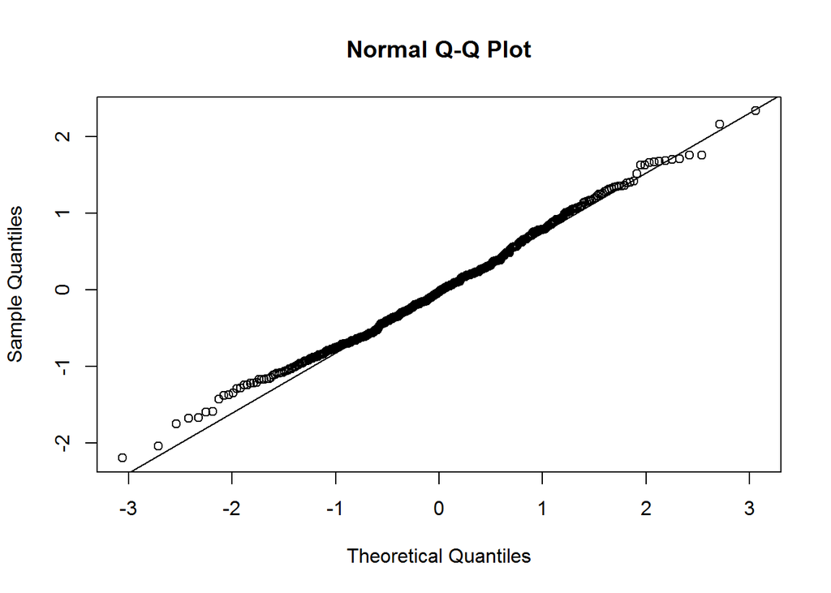

```r
qqnorm(lmod$residuals)
qqline(lmod$residuals)
```

Air temperature appears to be strong predictor, but the fit is poor ($R^2$ is low) and residuals are not normal.  
See how many anomalies, considering temperature is above median, the linear model detects and how they are distributed in time.

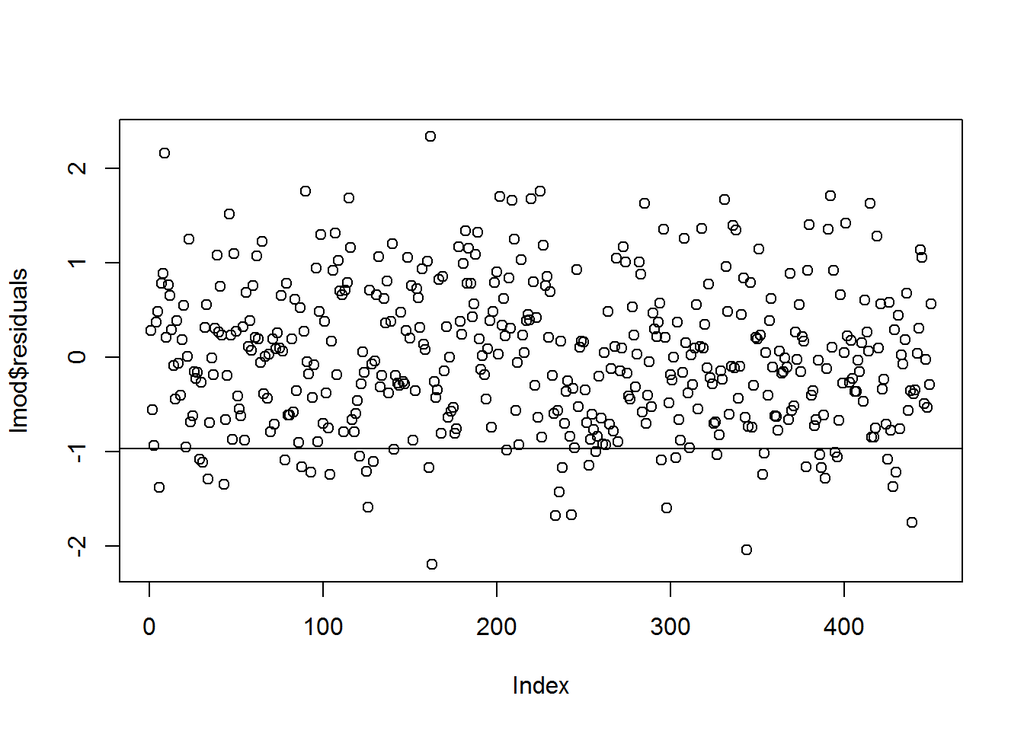

```r
plot(lmod$residuals)
abline(h=qnorm(.10)*sd(lmod$residuals))
```

```r
lmAnomalyIdx<-(lmod$residuals<qnorm(.10)*sd(lmod$residuals))&(temperMonLocatNorm>median(temperMonLocatNorm))
sum(lmAnomalyIdx)
```

```
## [1] 25
```

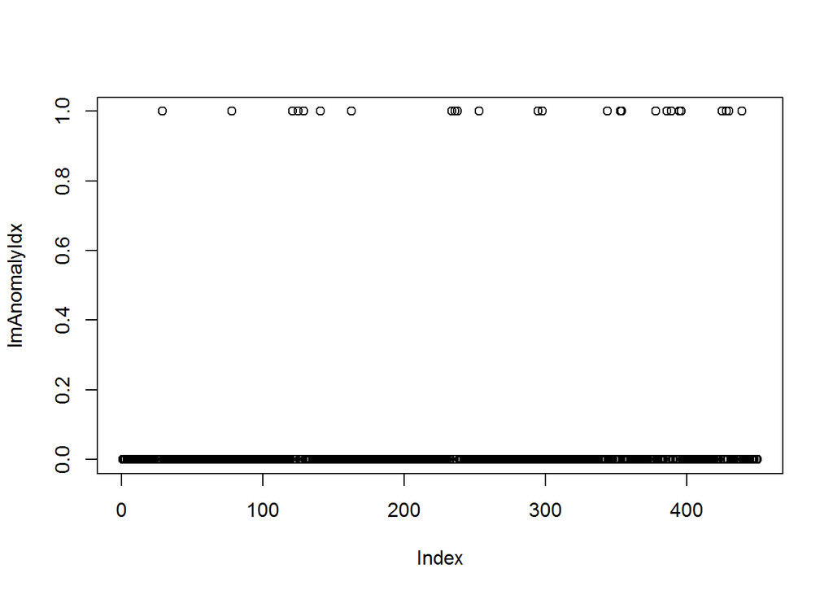

```r
plot(lmAnomalyIdx)
```

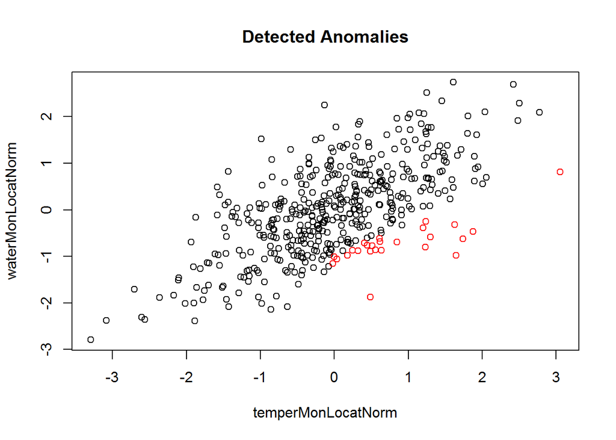

```r
plot(temperMonLocatNorm,waterMonLocatNorm,main="Detected Anomalies")
points(temperMonLocatNorm[lmAnomalyIdx],waterMonLocatNorm[lmAnomalyIdx],col="red")
```

Linear model observes significant number of points corresponding to either high-temperature-high-water or low-temperature-low-water. This makes it overestimate correlation, which in turn identifies even moderate deviations from regression line down as an outlier (below 10% quantile of the distribution of residuals).  
The number of anomalies is probably inflated and their distribution across time does not seem to change a lot.

## 5.2 Approach used in the article

The article by [Shih-Chieh Kao, Auroop R. Ganguly, and Karsten Steinhaeuser](https://pdfs.semanticscholar.org/13a9/c98368018401a39c17a6232a475f5ead95f5.pdf) follows the approach of detecting high-temperature-low-water anomalies using first an independence assumption for marginal distributions, setting 80% quantile for temperature and 20% quantile for water.

Application of the approach to empirical copula shows:

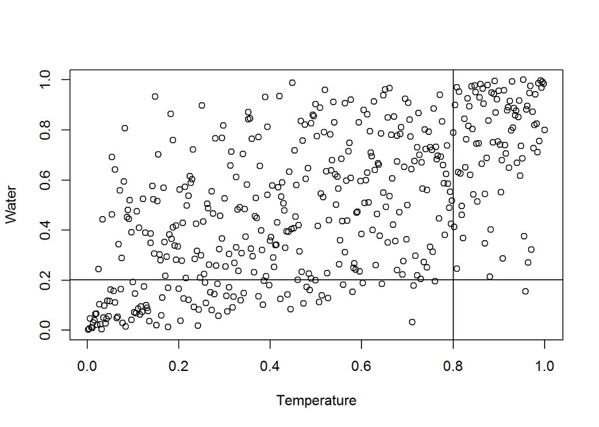

```r
highTemp<-quantile(temperMonLocatNorm,probs=.80)
lowWater<-quantile(waterMonLocatNorm,probs=.20)
highTempRank<-quantile(rank(temperMonLocatNorm)/nTime,.80)
lowWaterRank<-quantile(rank(waterMonLocatNorm)/nTime,.20)

#Coupla plot
plot(rank(temperMonLocatNorm)/nTime,rank(waterMonLocatNorm)/nTime,xlab="Temperature",ylab="Water")
abline(v=highTempRank)
abline(h=lowWaterRank)
```

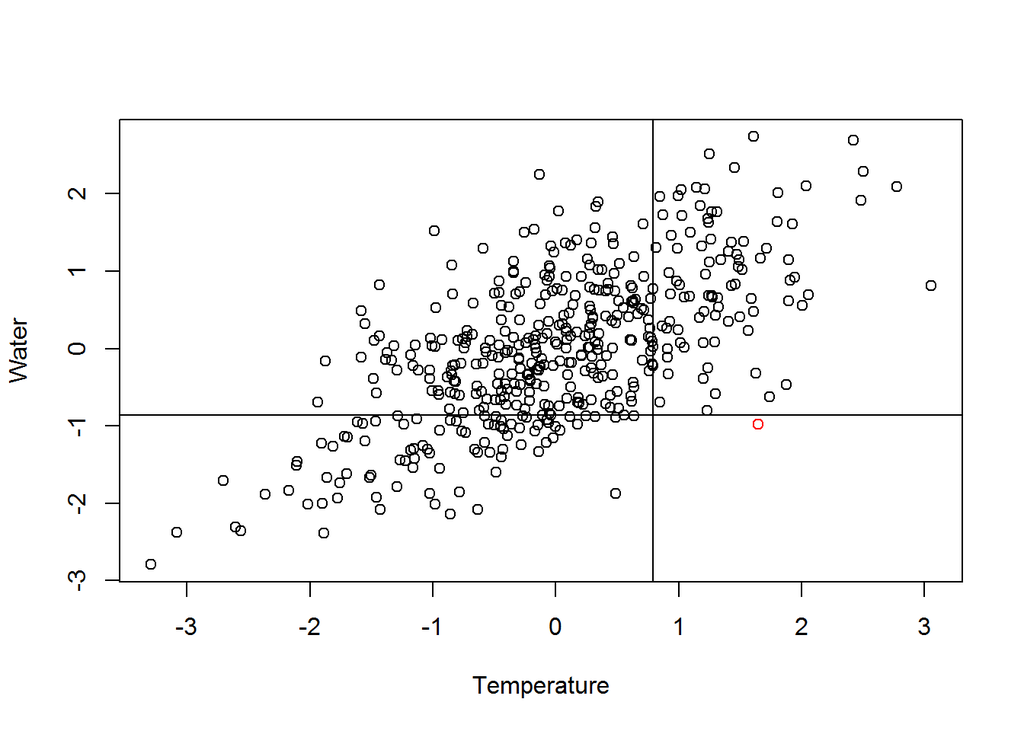

```r
#Data plot
anomIdx<-(temperMonLocatNorm>highTemp)&(waterMonLocatNorm<lowWater)
plot(temperMonLocatNorm,waterMonLocatNorm,xlab="Temperature",ylab="Water")
points(temperMonLocatNorm[anomIdx],waterMonLocatNorm[anomIdx],col="red")
abline(v=highTemp)
abline(h=lowWater)
```

Such approach detects only one anomaly in spite of pretty low 20% level of both tails.  
This approach is probably on the other side of the extreme from the linear model.

In the article the authors also make an adjustment of the 20% quantiles for the fitted copula (accounting for influence of the copula), but this did not seem to change the sensitivity of the detecting algorithm.

## 5.3 Using quantile regression

Select 5%, 95% and 50% levels and estimate quantiles of conditional distribution $P(V \le v | U=u)$, where [U,V] are the fitted Frank copula to the variables of temperature and water, using formulas in lecture slides.

```r
theta<-Frank.Copula.fit@estimate
alpha<-.05
tempRanks<-rank(temperMonLocatNorm)/nTime

lowBoundWater<-sapply(tempRanks,
                      function(z)
                        -log(1-alpha*(1-exp(-theta))/(exp(-theta*z)+alpha*(1-exp(-theta*z))))/theta)
alpha<-.95
highBoundWater<-sapply(tempRanks,
                      function(z)
                        -log(1-alpha*(1-exp(-theta))/(exp(-theta*z)+alpha*(1-exp(-theta*z))))/theta)
alpha<-.5
midBoundWater<-sapply(tempRanks,
                      function(z)
                        -log(1-alpha*(1-exp(-theta))/(exp(-theta*z)+alpha*(1-exp(-theta*z))))/theta)
```

Create empirical copula plot with upper, lower and median quantiles predicted by the fitted Frank copula.

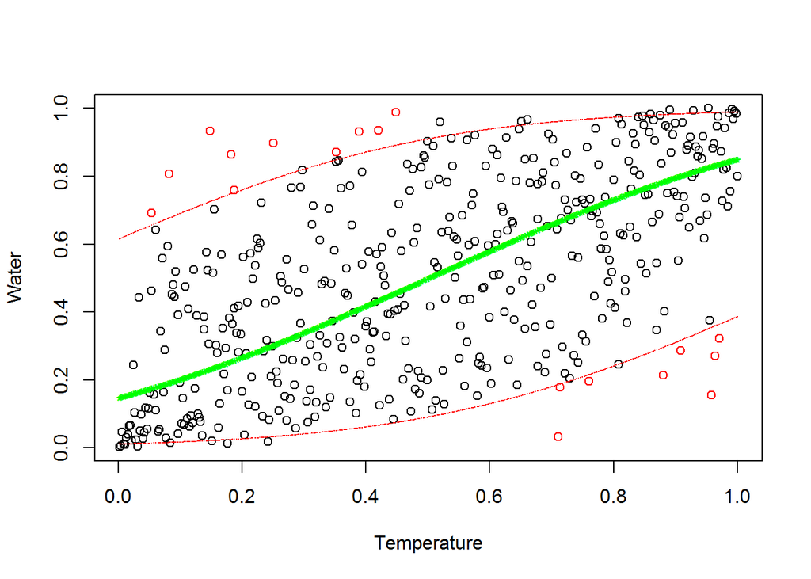

```r
anomLowWaterIdx<-(rank(waterMonLocatNorm)/nTime<lowBoundWater)&(rank(temperMonLocatNorm)/nTime>.5)
anomHighWaterIdx<-(rank(waterMonLocatNorm)/nTime>highBoundWater)&(rank(temperMonLocatNorm)/nTime<.5)
plot(rank(temperMonLocatNorm)/nTime,rank(waterMonLocatNorm)/nTime,xlab="Temperature",ylab="Water")
points(rank(temperMonLocatNorm)/nTime,lowBoundWater,col="red",pch=".")
points(rank(temperMonLocatNorm)/nTime,highBoundWater,col="red",pch=".")
points(rank(temperMonLocatNorm)/nTime,midBoundWater,col="green",pch="*",lwd=2)
points(rank(temperMonLocatNorm)[anomLowWaterIdx]/nTime,rank(waterMonLocatNorm)[anomLowWaterIdx]/nTime,col="red")
points(rank(temperMonLocatNorm)[anomHighWaterIdx]/nTime,rank(waterMonLocatNorm)[anomHighWaterIdx]/nTime,col="red")
```

Copula-based method detects a more realistic number and deviation of anomalies than other methods.

```r
sum(anomLowWaterIdx)/450
```

```
## [1] 0.01777778
```

```r
sum(anomHighWaterIdx)/450
```

```
## [1] 0.02222222
```

Number of detected anomalies with 5% levels on both sides is about 2% of the sample.

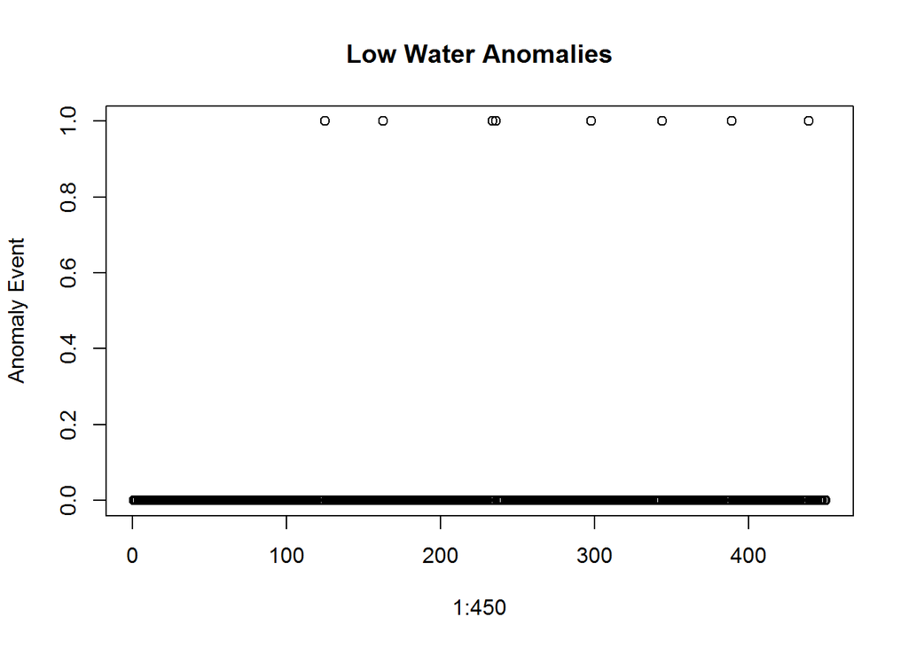

```r
plot(1:450,anomLowWaterIdx*1,main="Low Water Anomalies",ylab="Anomaly Event")
```

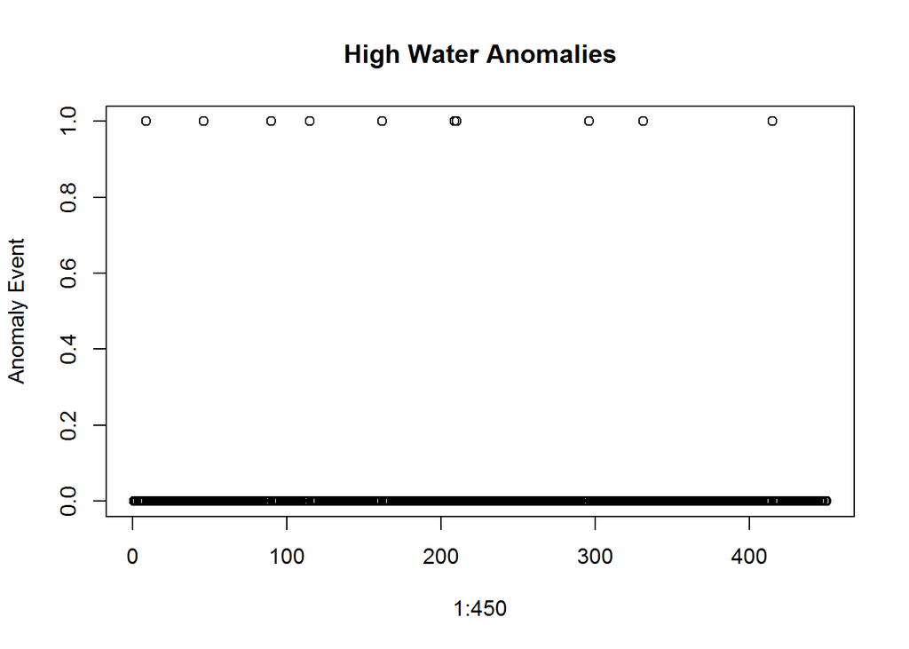

```r
plot(1:450,anomHighWaterIdx*1,main="High Water Anomalies",ylab="Anomaly Event")
```

High-water-low-temperature anomalies are more frequent during the initial period.  
Low-water-high-temperature anomalies are more frequent during the later period.

Months when low-water-high-temperature anomalies occurred are:

```r
temperDates[anomLowWaterIdx]
```

```
## [1]  5  7  6  8 10  8  5  7
```

Months when high-water-low-temperature anomalies occurred are:

```r
temperDates[anomHighWaterIdx]
```

```
##  [1]  9 10  6  7  6  5  6  8  7  7
```